# Homework 13: Logistic Regression

XDASI Fall 2021

Joseph Berkson [YOUR NAME HERE]

04 December, 2021

## Review

Before beginning this exercise, please review the lecture notes on logistic regression. In particular, you will want to re-read the sections on **Generalized linear models**, **GLM families**, and **ROC and AUC**.

## The Wisconsin Breast Cancer Dataset

The following data was obtained from a study where 3D images were taken of a breast mass. The features are measurements of the mass. We will try to create a logistic regression model to predict the **diagnosis** (M=malignant and B=benign). For a more detail understanding of the values see the link below:

https://www.kaggle.com/uciml/breast-cancer-wisconsin-data

## Q0: Exploratory analysis

The file is provided in as a csv file called *cancer_data.csv*. Read it in and call it **cancer_data**.

For visualization purposes, we prefer to show “malignant” samples in a warm color and “benign” samples in a cool color for all of our graphs. To do this, **set “stringsAsFactors” to FALSE** during the initial import, and then use the `factor()` function to explicitly set “M” as the first factor level for the “diagnosis” column.

*Note: for very large datasets, you may find it useful to take a quick look at the data using the `glimpse()` function as an alternative to `head()` and `View()`.*

```r
# load the dataset and inspect it
cancer_data = read.csv("cancer_data.csv", stringsAsFactors = FALSE)
cancer_data$diagnosis = factor(cancer_data$diagnosis,
                               levels = c("M","B"))
str(cancer_data)
```

```
## 'data.frame':    569 obs. of  32 variables:
##  $ id                     : int  842302 842517 84300903 84348301 84358402 843786 844359 84458202 844981 84501001 ...
##  $ diagnosis              : Factor w/ 2 levels "M","B": 1 1 1 1 1 1 1 1 1 1 ...
##  $ radius_mean            : num  18 20.6 19.7 11.4 20.3 ...
##  $ texture_mean           : num  10.4 17.8 21.2 20.4 14.3 ...
##  $ perimeter_mean         : num  122.8 132.9 130 77.6 135.1 ...
##  $ area_mean              : num  1001 1326 1203 386 1297 ...
##  $ smoothness_mean        : num  0.1184 0.0847 0.1096 0.1425 0.1003 ...
##  $ compactness_mean       : num  0.2776 0.0786 0.1599 0.2839 0.1328 ...
##  $ concavity_mean         : num  0.3001 0.0869 0.1974 0.2414 0.198 ...
##  $ concave.points_mean    : num  0.1471 0.0702 0.1279 0.1052 0.1043 ...
##  $ symmetry_mean          : num  0.242 0.181 0.207 0.26 0.181 ...
##  $ fractal_dimension_mean : num  0.0787 0.0567 0.06 0.0974 0.0588 ...
##  $ radius_se              : num  1.095 0.543 0.746 0.496 0.757 ...
##  $ texture_se             : num  0.905 0.734 0.787 1.156 0.781 ...
```

[output cut: 18 more lines]

```r
#head(cancer_data)
#glimpse(cancer_data)
#View(cancer_data)
```

### Data curation

Wow, that’s a lot of data! Let’s just keep the “diagnosis” column and the 10 columns containing the mean measurements (i.e. get rid of the “se” and “worst” columns).

Also, let’s shorten the column names for convenience. To do this, use the `sub()` function to replace “_mean” with ““, passing the column names of the `cancer_data` df as the object to be operated on.

*Hint: It’s always good to look up a function in the Help docs when you haven’t used it before.*

```r
# make the dataset smaller!
cancer_data = cancer_data[,2:12]
str(cancer_data)
```

```
## 'data.frame':    569 obs. of  11 variables:
##  $ diagnosis             : Factor w/ 2 levels "M","B": 1 1 1 1 1 1 1 1 1 1 ...
##  $ radius_mean           : num  18 20.6 19.7 11.4 20.3 ...
##  $ texture_mean          : num  10.4 17.8 21.2 20.4 14.3 ...
##  $ perimeter_mean        : num  122.8 132.9 130 77.6 135.1 ...
##  $ area_mean             : num  1001 1326 1203 386 1297 ...
##  $ smoothness_mean       : num  0.1184 0.0847 0.1096 0.1425 0.1003 ...
##  $ compactness_mean      : num  0.2776 0.0786 0.1599 0.2839 0.1328 ...
##  $ concavity_mean        : num  0.3001 0.0869 0.1974 0.2414 0.198 ...
##  $ concave.points_mean   : num  0.1471 0.0702 0.1279 0.1052 0.1043 ...
##  $ symmetry_mean         : num  0.242 0.181 0.207 0.26 0.181 ...
##  $ fractal_dimension_mean: num  0.0787 0.0567 0.06 0.0974 0.0588 ...
```

```r
# remove trailing "_mean" from the column names
colnames(cancer_data) = sub("_mean","",colnames(cancer_data))

# examine the resulting df
str(cancer_data)
```

```
## 'data.frame':    569 obs. of  11 variables:
##  $ diagnosis        : Factor w/ 2 levels "M","B": 1 1 1 1 1 1 1 1 1 1 ...
##  $ radius           : num  18 20.6 19.7 11.4 20.3 ...
##  $ texture          : num  10.4 17.8 21.2 20.4 14.3 ...
##  $ perimeter        : num  122.8 132.9 130 77.6 135.1 ...
##  $ area             : num  1001 1326 1203 386 1297 ...
##  $ smoothness       : num  0.1184 0.0847 0.1096 0.1425 0.1003 ...
##  $ compactness      : num  0.2776 0.0786 0.1599 0.2839 0.1328 ...
##  $ concavity        : num  0.3001 0.0869 0.1974 0.2414 0.198 ...
##  $ concave.points   : num  0.1471 0.0702 0.1279 0.1052 0.1043 ...
##  $ symmetry         : num  0.242 0.181 0.207 0.26 0.181 ...
##  $ fractal_dimension: num  0.0787 0.0567 0.06 0.0974 0.0588 ...
```

```r
head(cancer_data)
```

```
##   diagnosis radius texture perimeter   area smoothness compactness concavity
## 1         M  17.99   10.38    122.80 1001.0    0.11840     0.27760    0.3001
## 2         M  20.57   17.77    132.90 1326.0    0.08474     0.07864    0.0869
## 3         M  19.69   21.25    130.00 1203.0    0.10960     0.15990    0.1974
## 4         M  11.42   20.38     77.58  386.1    0.14250     0.28390    0.2414
## 5         M  20.29   14.34    135.10 1297.0    0.10030     0.13280    0.1980
## 6         M  12.45   15.70     82.57  477.1    0.12780     0.17000    0.1578
##   concave.points symmetry fractal_dimension
## 1        0.14710   0.2419           0.07871
## 2        0.07017   0.1812           0.05667
## 3        0.12790   0.2069           0.05999
## 4        0.10520   0.2597           0.09744
## 5        0.10430   0.1809           0.05883
## 6        0.08089   0.2087           0.07613
```

Whew! That’s better.

### Normalization

Let’s also **normalize** the data so that the values for each type of measurement are scaled relative to the mean and SD of each column. You can do this using the `scale()` function. Note that you can exclude the diagnosis column by negating it, or by specifying the desired column range explicitly.

*Note: For the sake of clarity, we will create a bunch of separate data frames for this exercise. An alternative would be to munge the original data frame by transforming / deleting / adding columns.*

```r
# normalize the data
scaled_data = data.frame(diagnosis = cancer_data$diagnosis,
                         scale(cancer_data[,-1]))

# alternative method
# scaled_data = cancer_data
# scaled_data[,-1] = scale(cancer_data[,-1])

str(scaled_data)
```

```
## 'data.frame':    569 obs. of  11 variables:
##  $ diagnosis        : Factor w/ 2 levels "M","B": 1 1 1 1 1 1 1 1 1 1 ...
##  $ radius           : num  1.096 1.828 1.578 -0.768 1.749 ...
##  $ texture          : num  -2.072 -0.353 0.456 0.254 -1.151 ...
##  $ perimeter        : num  1.269 1.684 1.565 -0.592 1.775 ...
##  $ area             : num  0.984 1.907 1.558 -0.764 1.825 ...
##  $ smoothness       : num  1.567 -0.826 0.941 3.281 0.28 ...
##  $ compactness      : num  3.281 -0.487 1.052 3.4 0.539 ...
##  $ concavity        : num  2.6505 -0.0238 1.3623 1.9142 1.3698 ...
##  $ concave.points   : num  2.53 0.548 2.035 1.45 1.427 ...
##  $ symmetry         : num  2.21557 0.00139 0.93886 2.86486 -0.00955 ...
##  $ fractal_dimension: num  2.254 -0.868 -0.398 4.907 -0.562 ...
```

```r
head(scaled_data)
```

```
##   diagnosis     radius    texture  perimeter       area smoothness compactness
## 1         M  1.0960995 -2.0715123  1.2688173  0.9835095  1.5670875   3.2806281
## 2         M  1.8282120 -0.3533215  1.6844726  1.9070303 -0.8262354  -0.4866435
## 3         M  1.5784992  0.4557859  1.5651260  1.5575132  0.9413821   1.0519999
## 4         M -0.7682333  0.2535091 -0.5921661 -0.7637917  3.2806668   3.3999174
## 5         M  1.7487579 -1.1508038  1.7750113  1.8246238  0.2801253   0.5388663
## 6         M -0.4759559 -0.8346009 -0.3868077 -0.5052059  2.2354545   1.2432416
##     concavity concave.points     symmetry fractal_dimension
## 1  2.65054179      2.5302489  2.215565542         2.2537638
## 2 -0.02382489      0.5476623  0.001391139        -0.8678888
## 3  1.36227979      2.0354398  0.938858720        -0.3976580
## 4  1.91421287      1.4504311  2.864862154         4.9066020
## 5  1.36980615      1.4272370 -0.009552062        -0.5619555
## 6  0.86554001      0.8239307  1.004517928         1.8883435
```

### Visualization

We are interested to find variables that will help us predict the diagnosis. Let’s make some exploratory plots to visualize how the data are distributed among *malignant* and *benign* outcomes.

First, use the`melt()` function in the `reshape2` package to get a “long” data frame with three columns: “diagnosis”, “variable”, and “value”.

Then, use `ggplot2` to create a boxplot for each variable by diagnosis using `facet_wrap` and/or `facet_grid`.

```r
#install.packages("reshape2") # uncomment to install (only needed once)
library(reshape2)

# melt the dataframe and take a look at it
scaled_data_melt = melt(scaled_data)
str(scaled_data_melt)
```

```
## 'data.frame':    5690 obs. of  3 variables:
##  $ diagnosis: Factor w/ 2 levels "M","B": 1 1 1 1 1 1 1 1 1 1 ...
##  $ variable : Factor w/ 10 levels "radius","texture",..: 1 1 1 1 1 1 1 1 1 1 ...
##  $ value    : num  1.096 1.828 1.578 -0.768 1.749 ...
```

```r
head(scaled_data_melt)
```

```
##   diagnosis variable      value
## 1         M   radius  1.0960995
## 2         M   radius  1.8282120
## 3         M   radius  1.5784992
## 4         M   radius -0.7682333
## 5         M   radius  1.7487579
## 6         M   radius -0.4759559
```

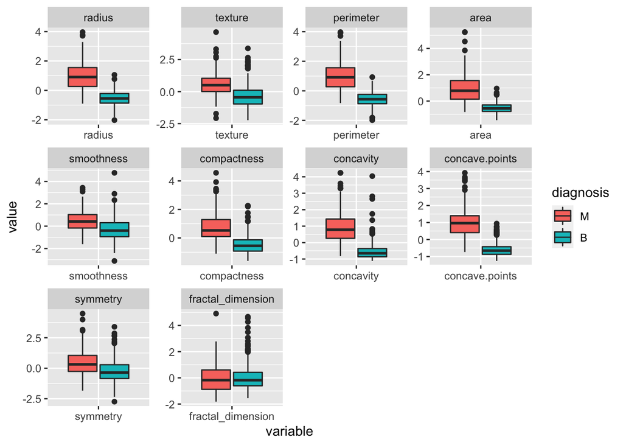

```r
# make multiple boxplots
ggplot(data = scaled_data_melt,
       aes(x = variable, y = value, fill = diagnosis)) +
  geom_boxplot() +
  facet_wrap(~variable, scale="free")
```

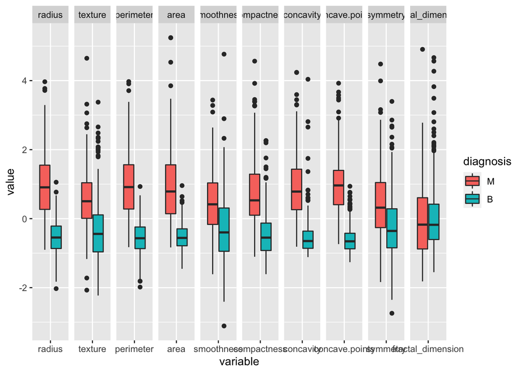

```r
ggplot(data = scaled_data_melt,
       aes(x = variable, y = value, fill = diagnosis)) +
  geom_boxplot() +
  facet_grid(~variable, scale="free")
```

Just by eyeballing the data, which of the features do you think should provide the most predictive power for the diagnosis outcome? Do any of the features look potentially uninformative? Explain your reasoning.

```r
# your answer here

"concave.points" seems to have the best separation between the benign and malignant cancer samples.

"fractal_dimension" seems to show no difference between the tumor classes.
```

### Remove uninformative features

First, use an appropriate test to determine whether the various measurements show any difference in the distributions of the B and M data.

*Hint: some of the data look like they may not be normally distributed, so don’t worry about checking this, just use a test that does not assume normality; in this case the test will have sufficient power to find any non-significant differences.*

*Note: you could use a `for` loop here so you don’t have to repeat your code a whole bunch of times. Optional: consider using `paste` or `paste0` to make the output more legible.*

```r
# p-value for observed difference between B and M outcomes for each feature
for (i in c(2:11)) {
  wt = wilcox.test(scaled_data[scaled_data$diagnosis == "B",i],
                   scaled_data[scaled_data$diagnosis == "M",i] )
  print(paste0(i,": ",colnames(scaled_data)[i]," = ",wt$p.value))
}
```

```
## [1] "2: radius = 2.69294277279662e-68"
## [1] "3: texture = 3.42862650474423e-28"
## [1] "4: perimeter = 3.55387022596389e-71"
## [1] "5: area = 1.53978036285896e-68"
## [1] "6: smoothness = 7.79300659558661e-19"
## [1] "7: compactness = 8.95199200522357e-48"
## [1] "8: concavity = 2.16454879062185e-68"
## [1] "9: concave.points = 1.00632370373404e-76"
## [1] "10: symmetry = 2.26805010674772e-15"
## [1] "11: fractal_dimension = 0.537185602135624"
```

Remove any columns from the scaled data frame that do not show a significant difference between the “B” and “M” samples.

```r
scaled_data = scaled_data[,-11] # remove last column ("fractal_dimension")
```

### Examine correlations

Take a look at how all the predictive variables correlate with each other using the `cor()` function (use Pearson correlation).

We can get even more fancy and plot the data using `ggpairs()` (this is done for you below).

```r
# just print out the correlations
cor(scaled_data[,2:10], method="pearson")
```

```
##                   radius     texture perimeter      area  smoothness
## radius         1.0000000  0.32378189 0.9978553 0.9873572  0.17058119
## texture        0.3237819  1.00000000 0.3295331 0.3210857 -0.02338852
## perimeter      0.9978553  0.32953306 1.0000000 0.9865068  0.20727816
## area           0.9873572  0.32108570 0.9865068 1.0000000  0.17702838
## smoothness     0.1705812 -0.02338852 0.2072782 0.1770284  1.00000000
## compactness    0.5061236  0.23670222 0.5569362 0.4985017  0.65912322
## concavity      0.6767636  0.30241783 0.7161357 0.6859828  0.52198377
## concave.points 0.8225285  0.29346405 0.8509770 0.8232689  0.55369517
## symmetry       0.1477412  0.07140098 0.1830272 0.1512931  0.55777479
##                compactness concavity concave.points   symmetry
## radius           0.5061236 0.6767636      0.8225285 0.14774124
## texture          0.2367022 0.3024178      0.2934641 0.07140098
## perimeter        0.5569362 0.7161357      0.8509770 0.18302721
## area             0.4985017 0.6859828      0.8232689 0.15129308
## smoothness       0.6591232 0.5219838      0.5536952 0.55777479
## compactness      1.0000000 0.8831207      0.8311350 0.60264105
## concavity        0.8831207 1.0000000      0.9213910 0.50066662
## concave.points   0.8311350 0.9213910      1.0000000 0.46249739
## symmetry         0.6026410 0.5006666      0.4624974 1.00000000
```

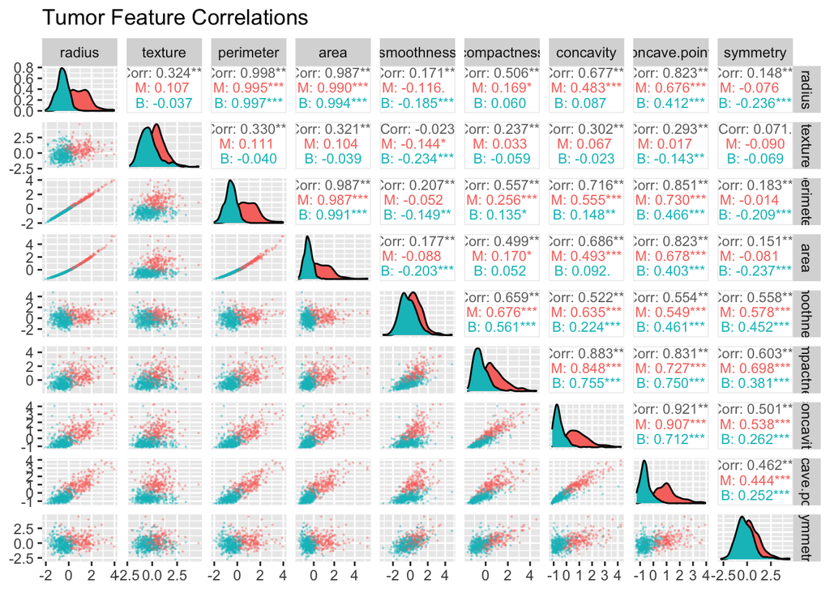

```r
# correlogram
#install.packages("GGally")  # only needed once
library(GGally)
ggpairs(scaled_data, columns = 2:10, title = "Tumor Feature Correlations",
        upper = list(continuous = wrap("cor",size = 3)),
        lower = list(continuous = wrap("points",
                                       alpha = 0.3,
                                       size = 0.1)),
        mapping = aes(color = diagnosis))
```

Looking at this pair-wise correlation graph, which variables look so highly correlated with each other that they are essentially redundant?

```r
# your answer here

Pairwise:
Radius/perimeter, radius/area, perimeter/area, concave points/concavity.

Groups:
- radius, area, perimeter (perimeter gives better separation based on wilcox.test)
- concavity and concave.points (concave.points better)
```

Which variables look *least* correlated with other variables? Are these the same ones that looked the best based on your boxplots and statistical tests above?

```r
# your answer here

- Texture looks the least correlated with other variables but did not look like it
had the most discriminating power above.
- Smoothness and symmetry look less correlated with most other variables also.

- After taking away highly correlated vars, radius/area/perimater look better.
- Concavity/concave.points show moderately high correlations with a bunch of other vars.
```

Why might you consider a dimensionality reduction method like PCA at this point?

```r
# your answer here

To focus on factors that are most likely to predict cancer outcomes, remove potential confounding variables and reduce chances of overfitting.
```

If we want to use individual features as predictors in a logistic model, why might we choose *not* to perform PCA at this step?

```r
# your answer here

Once we have performed PCA, we lose a little interpretability (even though we would find out which features contribute the most variability).
```

Another option to reduce the complexity of the dataset would be to simply manually remove some of the columns that are most highly correlated with other columns. Let’s keep this in mind, but let’s just continue with the remaining data for now.

## Q1: Prepare the data for modeling

To create our predictive models, we will use the `glm()` function, which stands for **generalized linear model**. Since logistic regression uses binary predictors, we will first encode all Benign outcomes as `0` and all Malignant outcomes as `1`.

### Recode binary outcomes

First, split the scaled data into two dataframes: `B_all` (all the Benign data) and `M_all` (all the Malignant data).

Then, recode the diagnosis outcomes as `0` for “B” and `1` for “M”.

```r
# subset the data based on B or M diagnosis
B_all = subset(scaled_data, diagnosis == "B")
M_all = subset(scaled_data, diagnosis == "M")

# recode the diagnoses as binary outcomes
B_all$diagnosis = 0
M_all$diagnosis = 1
```

### Create training and test datasets

For this exercise, we will train several predictive models on part of the data and hold out the rest of the data for testing the models to see which one gives the best predictions. Using hold-out data is a common way to test the quality of predictive models.

To generate the **training** and **test** datasets, we will randomly select 20% of the Benign samples and 20% of the Malignant samples and save them in a data frame called *BM_test*. The remaining samples will be stored in a different data frame called *BM_training*.

*Note: there are some data science packages that help with some of the steps below, but we will just do them the old-fashioned way here.*

```r
# select random samples: 80/20 split
set.seed(20211204)  # set a seed for reproducibility
B_sample = sample(1:nrow(B_all),
                  floor(0.2*nrow(B_all)))

set.seed(20211204)  # set a seed for reproducibility
M_sample = sample(1:nrow(M_all),
                  floor(0.2*nrow(M_all)))

# combine the test data into a single data.frame
BM_test = rbind(B_all[B_sample,],
                M_all[M_sample,])

# combine the training data into a single data.frame
# (use negation of test data sets)
BM_train = rbind(B_all[-B_sample,],
                 M_all[-M_sample,])

# make sure the diagnosis variable in each df is a FACTOR
BM_test$diagnosis = as.factor(BM_test$diagnosis)
BM_train$diagnosis = as.factor(BM_train$diagnosis)
```

## Q2: Binomial logistic regression

Now let’s build separate models for each variable alone using `BM_train`, and then build a model using all of the predictors together. Later, we will compare different models by evaluating their performance on the held-out test data.

General linear models come in **families** that describe the **link function** and **error distribution** for each model. Review the lecture notes on regression to refresh your memory about this. You should also check out the documentation on `glm()`.

Logistic regression actually uses an interative maximum likelihood estimation procedure. To make sure the models “converge”, we will also specify the number of iterations to perform using the `maxit` parameter. (You can test the models without including that parameter and see what happens.)

### Make alternative models

```r
# models with individual predictors
glm_radius      = glm(diagnosis ~ radius,
                      data = BM_train, family="binomial", maxit = 100)

glm_texture     = glm(diagnosis ~ texture,
                      data = BM_train, family="binomial", maxit = 100)

glm_perimeter   = glm(diagnosis ~ perimeter,
                      data = BM_train, family="binomial", maxit = 100)

glm_area        = glm(diagnosis ~ area,
                      data = BM_train, family="binomial", maxit = 100)

glm_smoothness  = glm(diagnosis ~ smoothness,
                     data = BM_train, family="binomial", maxit = 100)

glm_compactness = glm(diagnosis ~ compactness,
                      data = BM_train, family="binomial", maxit = 100)

glm_concavity   = glm(diagnosis ~ concavity,
                      data = BM_train, family="binomial", maxit = 100)

glm_concave.points = glm(diagnosis ~ concave.points,
                      data = BM_train, family="binomial", maxit = 100)

glm_symmetry    = glm(diagnosis ~ symmetry,
                      data = BM_train, family="binomial", maxit = 100)

# model with linear combination of all predictors (do not include interaction terms)
glm_all         = glm(diagnosis ~ . ,
                      data = BM_train, family="binomial", maxit = 100)
```

```
## Warning: glm.fit: fitted probabilities numerically 0 or 1 occurred
```

Huh. It looks like the full model gave us a warning. This is usually due to the presence of some extreme outliers in the data, so that predicted values cannot be distinguished from 0 or 1.

### Coefficients

You can look at the quality of the models using the `summary()` function, just like you did with linear regression. Do this with the full model above.

```r
summary(glm_all)
```

```
##
## Call:
## glm(formula = diagnosis ~ ., family = "binomial", data = BM_train,
##     maxit = 100)
##
## Deviance Residuals:
##      Min        1Q    Median        3Q       Max
## -1.77895  -0.14098  -0.03827   0.00234   2.80035
##
## Coefficients:
##                Estimate Std. Error z value Pr(>|z|)
## (Intercept)      1.0933     0.6753   1.619  0.10543
## radius         -13.5981    13.9509  -0.975  0.32970
## texture          1.9538     0.3639   5.369 7.94e-08 ***
## perimeter        0.9921    13.0117   0.076  0.93922
## area            19.2473     6.8014   2.830  0.00466 **
## smoothness       1.1885     0.5181   2.294  0.02179 *
## compactness     -0.4907     0.9143  -0.537  0.59146
## concavity        0.1241     0.6644   0.187  0.85178
## concave.points   3.0268     1.2269   2.467  0.01362 *
## symmetry         0.2904     0.3542   0.820  0.41231
## ---
## Signif. codes:  0 '***' 0.001 '**' 0.01 '*' 0.05 '.' 0.1 ' ' 1
##
## (Dispersion parameter for binomial family taken to be 1)
##
##     Null deviance: 602.31  on 455  degrees of freedom
## Residual deviance: 111.97  on 446  degrees of freedom
## AIC: 131.97
##
## Number of Fisher Scoring iterations: 9
```

### Reduce feature set

We can see from this that a few variables seem to have an outsized contribution to the model and also have a very large standard error. If we go back and look at our boxplots, we can see that “area” is the worst offender.

Since it’s highly correlated with two other variables, let’s just make a reduced model that includes all of the variables *except* area, and look at the summary for the new model.

```r
# reduced model (-area)
glm_reduced = glm(diagnosis ~ radius + texture + perimeter + smoothness +
                    compactness + concavity + concave.points + symmetry,
                    data = BM_train, family="binomial", maxit = 100)

summary(glm_reduced)
```

```
##
## Call:
## glm(formula = diagnosis ~ radius + texture + perimeter + smoothness +
##     compactness + concavity + concave.points + symmetry, family = "binomial",
##     data = BM_train, maxit = 100)
##
## Deviance Residuals:
##      Min        1Q    Median        3Q       Max
## -2.11368  -0.13365  -0.02996   0.01880   2.94982
##
## Coefficients:
##                Estimate Std. Error z value Pr(>|z|)
## (Intercept)     -0.6328     0.2658  -2.381   0.0173 *
## radius           3.4827    12.1811   0.286   0.7749
## texture          1.8712     0.3391   5.518 3.42e-08 ***
## perimeter        0.2534    12.8818   0.020   0.9843
## smoothness       1.2230     0.5602   2.183   0.0290 *
## compactness     -0.9850     0.9732  -1.012   0.3115
## concavity        0.9155     0.6534   1.401   0.1612
## concave.points   2.3744     1.1935   1.989   0.0466 *
## symmetry         0.3787     0.3557   1.065   0.2869
## ---
## Signif. codes:  0 '***' 0.001 '**' 0.01 '*' 0.05 '.' 0.1 ' ' 1
##
## (Dispersion parameter for binomial family taken to be 1)
##
##     Null deviance: 602.31  on 455  degrees of freedom
## Residual deviance: 119.87  on 447  degrees of freedom
## AIC: 137.87
##
## Number of Fisher Scoring iterations: 8
```

What looks different about this model?

```r
# your answer here

The coefficient for radius decreased dramatically and the other ones shifted around a bit.
```

While we’re at it, let’s go ahead and make a model containing just the non-redundant features. We can see from our correlation matrix above that “perimeter” and “concavity” both show a correlation >0.9 with other variables, so let’s make a new model that also excludes these two features and look at the summary.

```r
# logistic regression model (-area, -perimeter, -concavity)
glm_nonredundant = glm(diagnosis ~ radius + texture + smoothness +
                       compactness + concave.points + symmetry,
                       data = BM_train, family="binomial", maxit = 100)
summary(glm_nonredundant)
```

```
##
## Call:
## glm(formula = diagnosis ~ radius + texture + smoothness + compactness +
##     concave.points + symmetry, family = "binomial", data = BM_train,
##     maxit = 100)
##
## Deviance Residuals:
##      Min        1Q    Median        3Q       Max
## -2.33126  -0.13655  -0.03215   0.02328   2.86499
##
## Coefficients:
##                Estimate Std. Error z value Pr(>|z|)
## (Intercept)     -0.6525     0.2545  -2.564 0.010338 *
## radius           3.2471     0.7586   4.280 1.87e-05 ***
## texture          1.8358     0.3310   5.547 2.91e-08 ***
## smoothness       0.8508     0.4467   1.905 0.056803 .
## compactness     -0.6425     0.5149  -1.248 0.212063
## concave.points   3.3168     0.9446   3.511 0.000446 ***
## symmetry         0.4793     0.3460   1.385 0.166025
## ---
## Signif. codes:  0 '***' 0.001 '**' 0.01 '*' 0.05 '.' 0.1 ' ' 1
##
## (Dispersion parameter for binomial family taken to be 1)
##
##     Null deviance: 602.31  on 455  degrees of freedom
## Residual deviance: 121.66  on 449  degrees of freedom
## AIC: 135.66
##
## Number of Fisher Scoring iterations: 8
```

What did this do to the coefficients and the p-values for the remaining non-redundant variables? What do the results suggest about the contribution of different features to the full model?

```r
# your answer here

Removing redundant variables made the remaining ones from those sets more significant.

Some of the redundant features contribute little to the overall model and can
probably be safely discarded.
```

If we were really working on this dataset for real, we would explore these issues more deeply, but for the purposes of this exercise let’s just move on.

## Q3: Evaluate model performance

### Predict using held-out data

To test our models, we will apply the `predict.glm()` function to the **BM_test** dataset. The default prediction `type` uses the scale of the linear predictors. We’ll use the scale of the **“response”** variable instead.

*Note: The `predict()` function is short-hand for a variety of more specific prediction functions; it will figure out the class of model from the object passed as the first parameter.*

First, make predictions using each of the remaining predictors in the “nonredundant” feature set individually. Then, make predictive models using all of the nonredundant features together.

```r
## Individual predictors
cancer_pred_radius  = predict(glm_radius,
                              newdata = BM_test, type="response")

cancer_pred_texture    = predict(glm_texture,
                                 newdata = BM_test, type="response")

cancer_pred_smooth     = predict(glm_smoothness,
                                 newdata = BM_test, type="response")

cancer_pred_compact    = predict(glm_compactness,
                                 newdata = BM_test, type="response")

cancer_pred_concave.points  = predict(glm_concave.points,
                                 newdata = BM_test, type="response")

cancer_pred_symmetry   = predict(glm_symmetry,
                                 newdata = BM_test, type="response")

# nonredundant features
cancer_pred_nonredundant = predict(glm_nonredundant,
                                   newdata = BM_test, type="response")
```

Great! Now we have some predictive models! What’s next? Below we will explore some of the different ways we can evaluate the results of our predictions.

### Histogram

Let’s take a quick look at our predictions for the full “nonredundant” model:

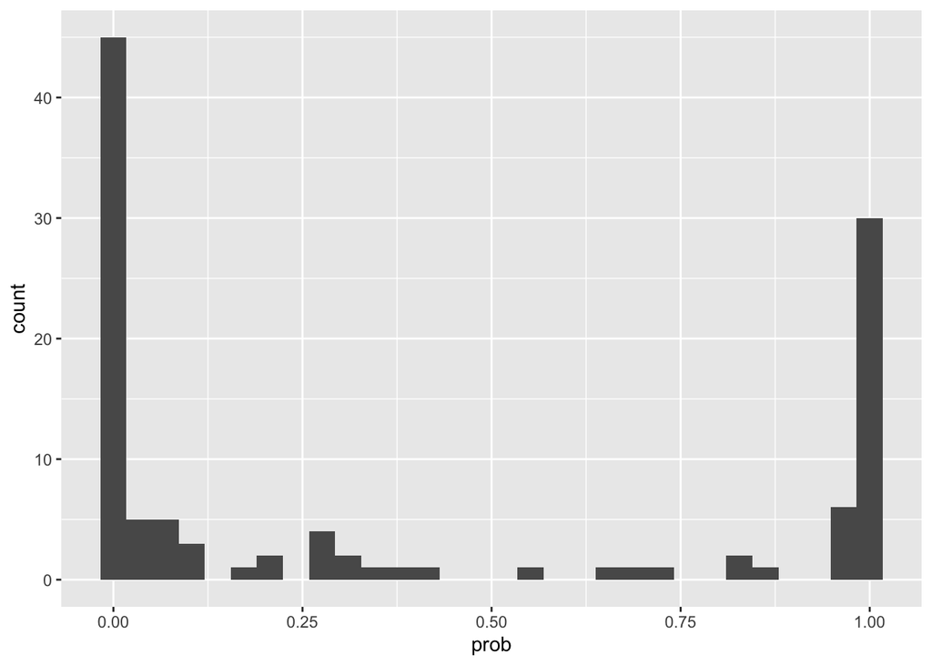

```r
ggplot(data.frame(prob=cancer_pred_nonredundant)) +
  geom_histogram(aes(x=prob))
```

What does this plot show?

```r
# your answer here

The plot shows that the model is pretty confident about most of the test data, but it has a hard time deciding on the diagnosis for some of them.
```

### Confusion matrix

We can look at the **confusion matrix**, which is just a table of true or false positives and negatives at a particular probability cutoff. Check this out for the full prediction model (`cancer_pred_nonredundant`) at 20%, 50%, and 80% probability cutoffs.

```r
# 20% probability
neg_pos = as.numeric(cancer_pred_nonredundant >= 0.2)
table(neg_pos)                    # predictions
```

```
## neg_pos
##  0  1
## 61 52
```

```r
table(neg_pos, BM_test$diagnosis) # predictions vs. observed
```

```
##
## neg_pos  0  1
##       0 60  1
##       1 11 41
```

```r
# 50% probability
neg_pos = as.numeric(cancer_pred_nonredundant >= 0.5)
table(neg_pos)
```

```
## neg_pos
##  0  1
## 70 43
```

```r
table(neg_pos, BM_test$diagnosis)
```

```
##
## neg_pos  0  1
##       0 66  4
##       1  5 38
```

```r
# 80% probability
neg_pos = as.numeric(cancer_pred_nonredundant >= 0.8)
table(neg_pos)
```

```
## neg_pos
##  0  1
## 74 39
```

```r
table(neg_pos, BM_test$diagnosis)
```

```
##
## neg_pos  0  1
##       0 69  5
##       1  2 37
```

How do the false negative and false positives change as the threshold is increased?

```r
# your answer here

As the stringency of the threshold is increased, the number of false positives
goes down, but the number of false negatives goes up.
```

### ROC and AUC

Another way we can assess performance is using the **AUC (area under the curve)** of a kind of plot that is strangely named a **ROC (Receiver Operating Characteristic)** plot. An **ROC plot** compares **sensivity (TP rate)** on the $y$-axis vs. **1-specificity (FP rate)** on the $x$-axis.

If our predictions are no better than random, then we would have an $AUC = 0.5$. We can visualize this by plotting a line from coordinates `0,0` to `1,1`. A straight line with a slope of 1 represents events that would happen just by chance.

On the other hand, curves that run higher and to the left will have a higher AUC and greater preditive power. So ideally, we will find a good model that has an ROC curve with a much larger area underneath it than the $AUC = 0.5$ line.

To evaluate our models, we will use the `roc()` command in the **AUC** package to compare the **Predicted** values with the **True** values. Once the ROC object is returned, we can get lots of different types of statistics, including **AUC** (by using the `auc()` function), TPR, FPR, specificity, sensitivity, accuracy, etc. and also a plot.

```r
# install.packages("AUC")  # uncomment to install (you only need to do this once)
library(AUC)
```

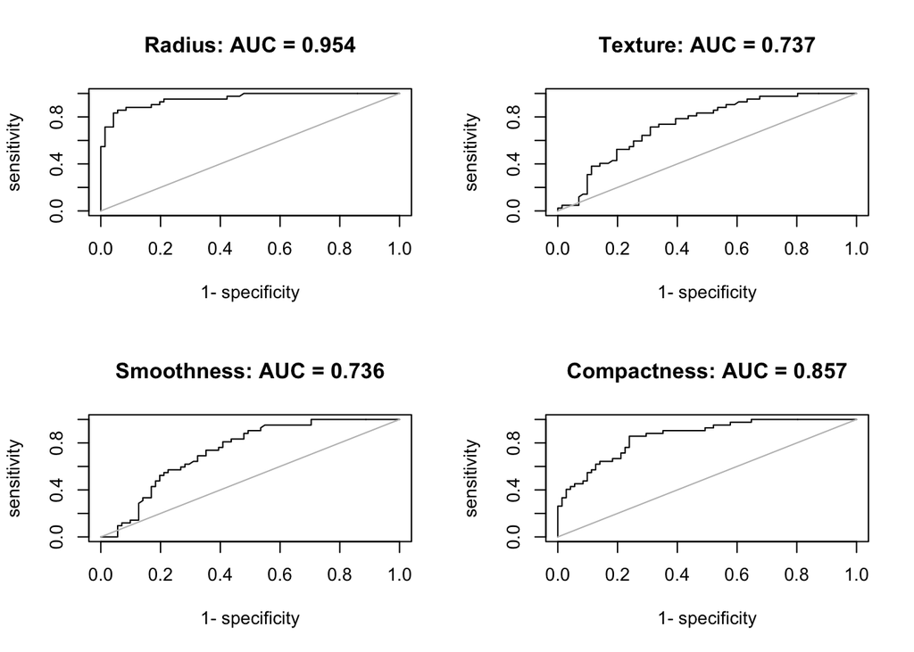

```r
# set up the plots
par(mfrow=c(2,2))

## individual predictors ===================================================== #

# compare PREDICTIONS on held-out data with TRUE data from BM_test

# radius
type = "Radius"
roc_result = roc(cancer_pred_radius, BM_test$diagnosis)
plot(roc_result, main=paste(type, ": AUC = ", signif(auc(roc_result),3), sep=""))

# texture
type = "Texture"
roc_result = roc(cancer_pred_texture, BM_test$diagnosis)
plot(roc_result, main=paste0(type, ": AUC = ", signif(auc(roc_result),3)))

# smoothness
type = "Smoothness"
roc_result = roc(cancer_pred_smooth, BM_test$diagnosis)
plot(roc_result, main=paste0(type, ": AUC = ", signif(auc(roc_result),3)))

# compactness
type = "Compactness"
roc_result = roc(cancer_pred_compact, BM_test$diagnosis)
plot(roc_result, main=paste0(type, ": AUC = ", signif(auc(roc_result),3)))
```

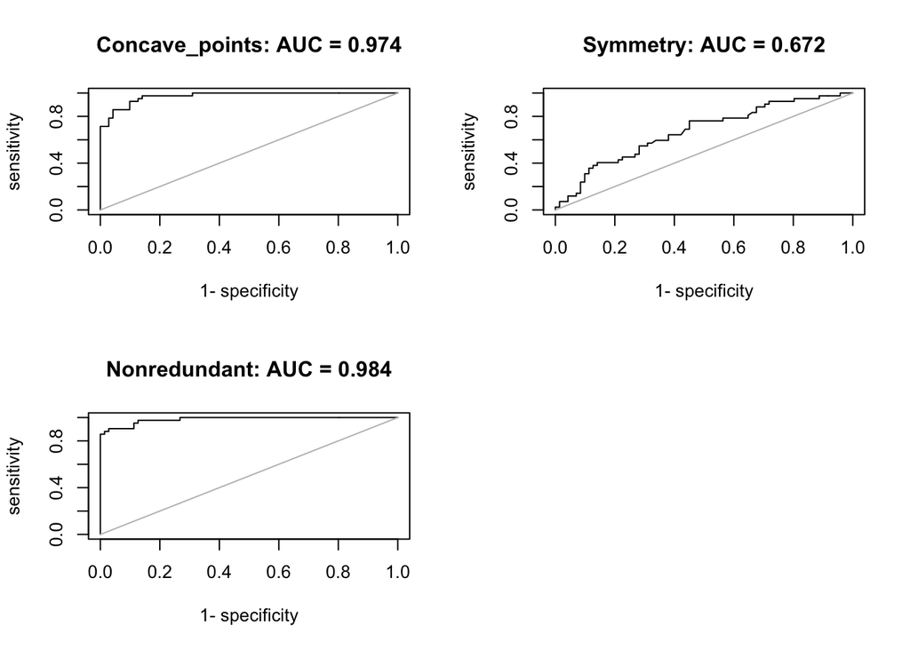

```r
par(mfrow=c(2,2))

# concave points
type = "Concave_points"
roc_result = roc(cancer_pred_concave.points, BM_test$diagnosis)
plot(roc_result, main=paste0(type, ": AUC = ", signif(auc(roc_result),3)))

# symmetry
type = "Symmetry"
roc_result = roc(cancer_pred_symmetry, BM_test$diagnosis)
plot(roc_result, main=paste0(type, ": AUC = ", signif(auc(roc_result),3)))


## combined predictors ======================================================= #
type = "Nonredundant"
roc_result = roc(cancer_pred_nonredundant, BM_test$diagnosis)
plot(roc_result, main=paste0(type, ": AUC = ", signif(auc(roc_result),3)))
```

Comment on the performance of these models. Which one is best? Explain why you think this is the case.

```r
# your answer here

The full nonredundant model looks best, since it contains the most information.
However a couple of the individual features seem to do almost as well.
```

## Q4: Model refinement

Using the summary of the full model as a guide, now make a model with just a subset of the strongest 3 predictors. Then, compare the model summary with the full nonredundant model and plot the ROC curve for the two models together.

- Compare the model summaries.
- Then, use both models to make predictions on the held-out data.
- Plot the ROC curves for the two models.

```r
# generate all the objects and plots for models with top 4 or 5 predictors, as above

## top 3 predictors ======================================================= ##
glm_top.features = glm(diagnosis ~ radius + compactness + concave.points,
               data = BM_train, family="binomial", maxit = 100)

summary(glm_top.features)
```

```
##
## Call:
## glm(formula = diagnosis ~ radius + compactness + concave.points,
##     family = "binomial", data = BM_train, maxit = 100)
##
## Deviance Residuals:
##      Min        1Q    Median        3Q       Max
## -2.50676  -0.24305  -0.09201   0.05843   2.55903
##
## Coefficients:
##                Estimate Std. Error z value Pr(>|z|)
## (Intercept)     -0.4132     0.2039  -2.026   0.0427 *
## radius           2.2551     0.4779   4.719 2.37e-06 ***
## compactness     -0.3767     0.4064  -0.927   0.3540
## concave.points   3.6577     0.6685   5.472 4.46e-08 ***
## ---
## Signif. codes:  0 '***' 0.001 '**' 0.01 '*' 0.05 '.' 0.1 ' ' 1
##
## (Dispersion parameter for binomial family taken to be 1)
##
##     Null deviance: 602.31  on 455  degrees of freedom
## Residual deviance: 170.08  on 452  degrees of freedom
## AIC: 178.08
##
## Number of Fisher Scoring iterations: 7
```

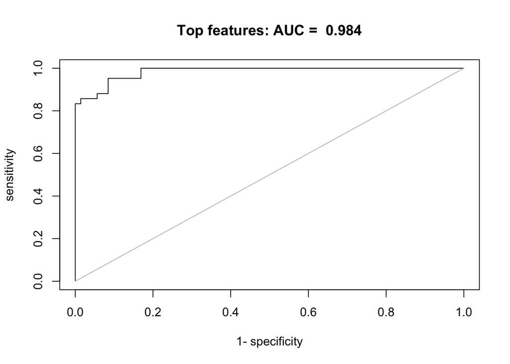

```r
cancer_pred_top.features = predict(glm_top.features,
                           newdata = BM_test, type="response")

roc_result_top.features = roc(cancer_pred_top.features, BM_test$diagnosis)
plot(roc_result_top.features, main=paste("Top features: AUC = ",
                            signif(auc(roc_result_top.features),3), sep=" "))
```

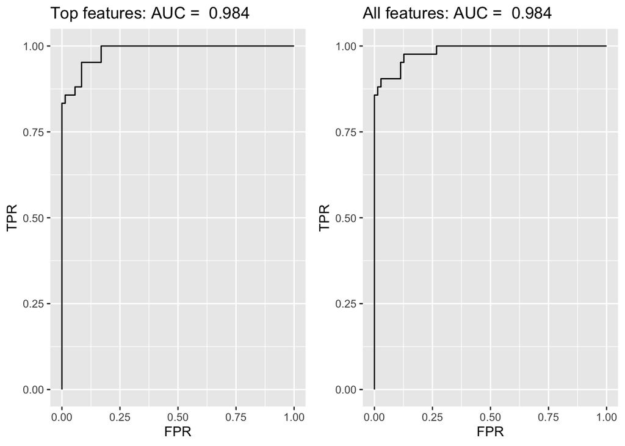

```r
roc_result_nonredundant = roc(cancer_pred_nonredundant, BM_test$diagnosis)

## alternative method for plotting with ggplot ##########################
# install.packages("ggpubr")  # only need to do this once
library(ggpubr)
# theme_set(theme_pubr())

p1 = ggplot(data.frame(FPR=roc_result_top.features$fpr,
                       TPR=roc_result_top.features$tpr)) +
     geom_line(aes(x=FPR, y=TPR)) +
     ggtitle(paste("Top features: AUC = ", signif(auc(roc_result_top.features),3), sep=" "))

p2 = ggplot(data.frame(FPR=roc_result_nonredundant$fpr,
                       TPR=roc_result_nonredundant$tpr)) +
     geom_line(aes(x=FPR, y=TPR)) +
     ggtitle(paste("All features: AUC = ", signif(auc(roc_result_nonredundant),3), sep=" "))

ggarrange(p1, p2, nrow = 1, ncol = 2)
```

How do these models compare? Would you rather choose the model with as much non-redundant information as possible, or choose the model with fewer predictors? What are the tradeoffs? Explain your reasoning.

```r
# your answer here.

In this case, the top 3 predictors seem to do just about as well as the full model.

Occam's razor would suggest using the simplest model possible. Using a lot of
predictors can lead to "overfitting", where the model is optimized for the
training data but performs less well on new data.
```

### ANOVA

Just like with linear models, you can also compare two logistic models with the `anova()` function, using the “Chisq” test. Compare the full nonredundant model with one or more of the individual models, and then compare it with the reduced model you just created using the top 3 predictors.

*Note: Remember that when comparing models, you always want to compare the more complex model to the simpler model, so you have to list the simpler model first.*

```r
# simple vs glm_nonredundant
anova(glm_texture, glm_nonredundant, test = "Chisq")
```

```
## Analysis of Deviance Table
##
## Model 1: diagnosis ~ texture
## Model 2: diagnosis ~ radius + texture + smoothness + compactness + concave.points +
##     symmetry
##   Resid. Df Resid. Dev Df Deviance  Pr(>Chi)
## 1       454     508.53
## 2       449     121.66  5   386.88 < 2.2e-16 ***
## ---
## Signif. codes:  0 '***' 0.001 '**' 0.01 '*' 0.05 '.' 0.1 ' ' 1
```

```r
anova(glm_area, glm_nonredundant, test = "Chisq")
```

```
## Analysis of Deviance Table
##
## Model 1: diagnosis ~ area
## Model 2: diagnosis ~ radius + texture + smoothness + compactness + concave.points +
##     symmetry
##   Resid. Df Resid. Dev Df Deviance  Pr(>Chi)
## 1       454     265.63
## 2       449     121.66  5   143.97 < 2.2e-16 ***
## ---
## Signif. codes:  0 '***' 0.001 '**' 0.01 '*' 0.05 '.' 0.1 ' ' 1
```

```r
anova(glm_compactness, glm_nonredundant, test = "Chisq")
```

```
## Analysis of Deviance Table
##
## Model 1: diagnosis ~ compactness
## Model 2: diagnosis ~ radius + texture + smoothness + compactness + concave.points +
##     symmetry
##   Resid. Df Resid. Dev Df Deviance  Pr(>Chi)
## 1       454     407.97
## 2       449     121.66  5   286.31 < 2.2e-16 ***
## ---
## Signif. codes:  0 '***' 0.001 '**' 0.01 '*' 0.05 '.' 0.1 ' ' 1
```

```r
# glm_top.features vs. glm_nonredundant
anova(glm_top.features, glm_nonredundant, test = "Chisq")
```

```
## Analysis of Deviance Table
##
## Model 1: diagnosis ~ radius + compactness + concave.points
## Model 2: diagnosis ~ radius + texture + smoothness + compactness + concave.points +
##     symmetry
##   Resid. Df Resid. Dev Df Deviance  Pr(>Chi)
## 1       452     170.08
## 2       449     121.66  3   48.426 1.728e-10 ***
## ---
## Signif. codes:  0 '***' 0.001 '**' 0.01 '*' 0.05 '.' 0.1 ' ' 1
```

From this analysis, can you decide which model seems best? Explain you reasoning.

```r
# your answer here

Even though they gave a similar AUC, it looks like the full redundant model is
better than the one with the top 3 predictors.
```

### AIC

**Akaike’s Information Criterion** can help with model selection by providing a measure of goodness-of-fit vs. model simplicity, which balances over- and under-fitting. AIC is computed as $-2*ln(likelihood)+2*k$, where k is the number of estimated parameters. AIC is based on information theory, and a lower AIC means that less information is lost, which is better.

AIC is included in the results of the `summary()` function for a general linear model. Compare the AIC from the full model with the AIC from the model using just the top 3 predictors (use the special dollar sign notation to get the `aic` value from the `glm` model).

```r
summary(glm_top.features)$aic
```

```
## [1] 178.0827
```

```r
summary(glm_nonredundant)$aic
```

```
## [1] 135.6563
```

Does this change your viewpoint on which model is best? Which model would you choose based on this criterion?

*Note: I don’t get the same results every time I knit this document! This is because some of these processes include some stochasticity. So, you may want to re-run the analysis a few times … even though the results will vary a little bit, overall the broad picture should be similar.*

```r
# your answer here

The full model still looks better by this criterion.
```